# Lesson 1 Basics

Julie Raiguel

January 16, 2018

## R Markdown

“tgpp” is the variable used for the dataset. The CSV file was read from the data directory within the project directory. When I ran this during class with only one dot it worked, but when I opened it at home, it would only work when I added a second dot. To make this code useful from other machines, I decided to read the dataset using the URL instead.

```r
tgpp <- read.csv("https://raw.githubusercontent.com/dmcglinn/quant_methods/gh-pages/data/tgpp.csv")
```

The “names” function returns the headers.

```r
names(tgpp)
```

```
##  [1] "plot"      "year"      "record_id" "corner"    "scale"
##  [6] "richness"  "easting"   "northing"  "slope"     "ph"
## [11] "yrsslb"
```

The “nrow” and “ncol” functions return the numbers of rows and columns.

```r
nrow(tgpp)
```

```
## [1] 4080
```

```r
ncol(tgpp)
```

```
## [1] 11
```

The “apply” functions execute a function for each of the columns in the dataset. In this case, I needed to know the classification of the data in the column. “lapply” returns the output as a list, which I find easier to read than the simplified version outputted by “sapply”.

```r
lapply(tgpp, class)
```

```
## $plot
## [1] "integer"
##
## $year
## [1] "integer"
##
## $record_id
## [1] "integer"
##
## $corner
## [1] "integer"
##
## $scale
## [1] "numeric"
##
## $richness
## [1] "integer"
##
## $easting
## [1] "integer"
##
## $northing
## [1] "integer"
##
## $slope
## [1] "integer"
##
## $ph
## [1] "numeric"
##
## $yrsslb
## [1] "numeric"
```

```r
sapply(tgpp, class)
```

```
##      plot      year record_id    corner     scale  richness   easting
## "integer" "integer" "integer" "integer" "numeric" "integer" "integer"
##  northing     slope        ph    yrsslb
## "integer" "integer" "numeric" "numeric"
```

```r
tgpp[c(1,5,8), c(3,7,10)]
```

```
##   record_id easting  ph
## 1       187  727000 6.9
## 5       191  727000 6.9
## 8       194  727000 6.9
```

The “pdf” command should make a pdf of the plot with the name “richness_scale_plot1.pdf” in the working directory.

The next line plots the data from the “Scale” column on the x-axis and the “Richness” column on the y-axis. The x and y axes are labeled the same as the respective columns, but the units of “Scale” are indicated. Only points are included, not lines, and the color of these points is “seagreen4”.

```r
pdf('./richness_scale_plot1.pdf')
plot(tgpp$scale, tgpp$richness, xlab = 'Scale (m^2)', ylab = 'Richness', type = 'p', col = 'seagreen4')
```

I repeat the plot line below so that the output is visible in the html file, not just in the new pdf file.

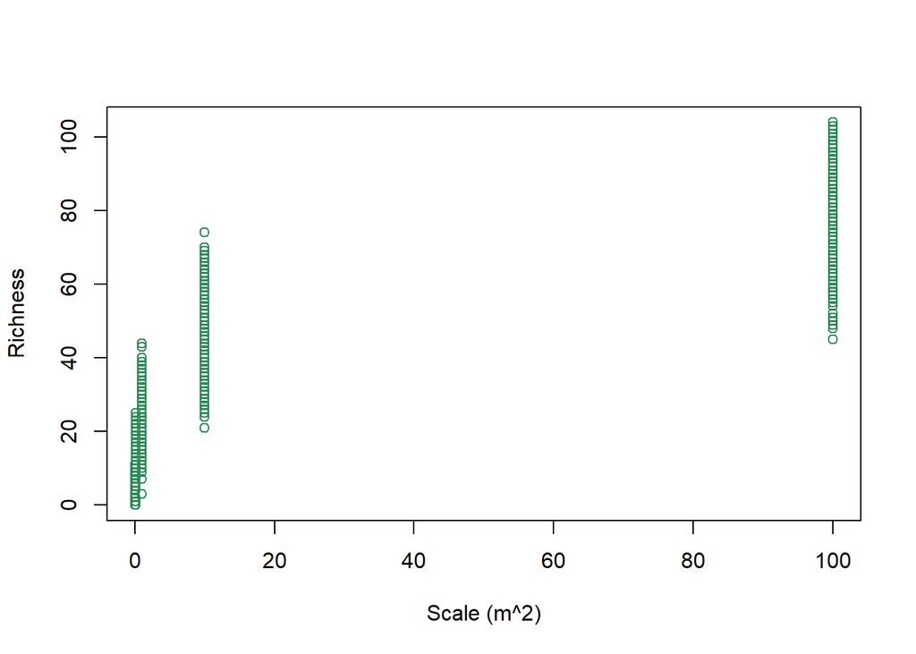

```r
plot(tgpp$scale, tgpp$richness, xlab = 'Scale (m^2)', ylab = 'Richness', type = 'p', col = 'seagreen4')
```

It is now not so skewed due to the wide range of areas that were sampled, so trends in the data are easier to see in the plot. R omits the four data points where the richness equals 0 because these are undefined when converted to log scale.

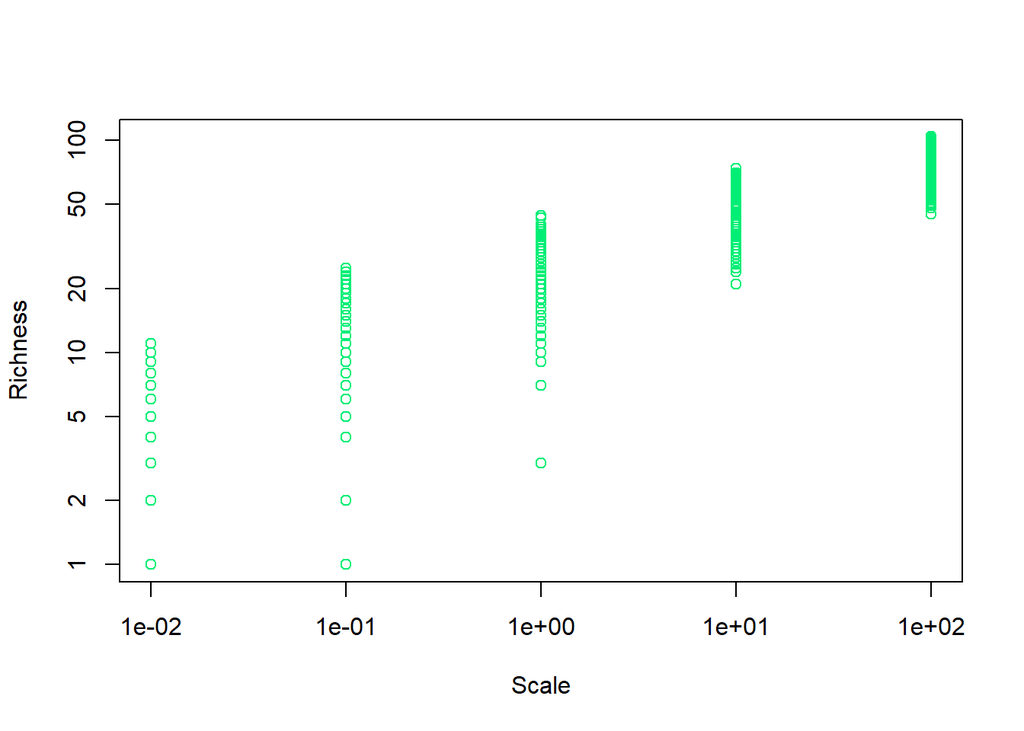

```r
plot(tgpp$scale, tgpp$richness, xlab = 'Scale', ylab = 'Richness', type = 'p', col = 'springgreen2', log='xy')
```